# 算法训练营Day 6

Author

Siru Wu

Published

January 19, 2026

今天是第三章 **哈希表**

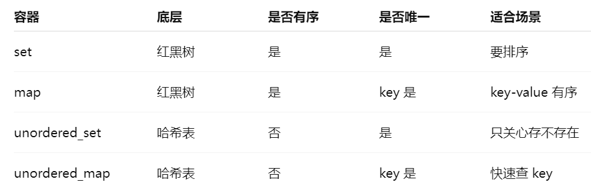

## [242 有效的字母异位词](https://leetcode.cn/problems/valid-anagram/description/)

> 给定两个字符串 s 和 t ，编写一个函数来判断 t 是否是 s 的字母异位词。

> 示例 1: 输入: s = “anagram”, t = “nagaram” 输出: true

> 示例 2: 输入: s = “rat”, t = “car” 输出: false

> 说明: **你可以假设字符串只包含小写字母**

### Python写法1：ASCII

```python
class Solution:
    def isAnagram(self, s, t):
        """
        :type s: str
        :type t: str
        :rtype: bool
        """
        record = [0] * 26 # a-z有26个字母
        for i in s:
            record[ord(i) - ord('a')] += 1 # 这里题目保证了input只有 a-z 的字母输入, 才可以这样写

        for i in t:
            record[ord(i) - ord('a')] -= 1 # 如果有的字母s里面没有但是t里面有，那那个index对应的值就不为0，那么后面就可以用 if record[i] != 0 来检查是否有不一样的值

        for i in range(26):
            if record[i] != 0:
                return False

        return True # 这一句跟上面的for并排是因为要检查完26个index发现没有false之后才返回true
```

### Python 写法2：Counter

```python
from collections import Counter

class Solution:
    def isAnagram(self, s: str, t: str) -> bool:
        a_count = Counter(s)
        b_count = Counter(t)

        return a_count == b_count
```

## [349 两个数组的交集](https://leetcode.cn/problems/intersection-of-two-arrays/description/)

> 给定两个数组 nums1 和 nums2 ，返回 它们的 交集 。输出结果中的每个元素一定是 唯一 的。我们可以 不考虑输出结果的顺序 。

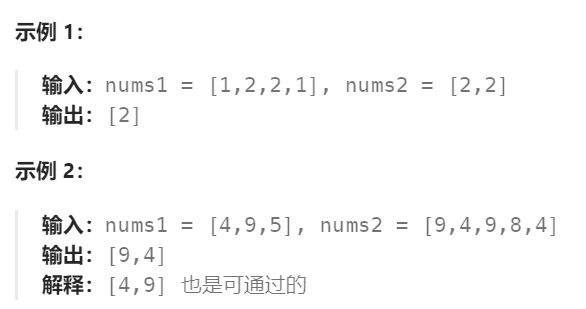

- **set 用 add**
- **list 用 append**

### 版本1：字典和集合

```python
# 题目里面说元素唯一，set的一个特性就是 不允许重复key
# set：只存 key
# map：存 key + value

class Solution(object):
    def intersection(self, nums1, nums2):
        """
        :type nums1: List[int]
        :type nums2: List[int]
        :rtype: List[int]
        """
        table = {}
        for num in nums1:
            table[num] = table.get(num, 0) + 1 # 这里table.get要用圆括号() 而不是[]

        # 这是第二种写法

        # table = set(nums1)
        # res = set()

        # for num in nums2:
            # if num in table:
            #     res.add(num)
            #     table.remove(num)
        # return list(res)

        res = set()
        for num in nums2:
            if num in table:
                res.add(num) # set 用 add
                del table[num]

        return list(res) # 这个地方必须用list转成List，不然res输出是个set
```

### 版本2：集合

```python
class Solution:
    def intersection(self, nums1: List[int], nums2: List[int]) -> List[int]:
        return list(set(nums1) & set(nums2))
```

### 版本3：数组

```python
# 本题后面 力扣改了 题目描述 和 后台测试数据，增添了 数值范围：
# 1 <= nums1.length, nums2.length <= 1000
# 0 <= nums1[i], nums2[i] <= 1000
# 所以就可以 使用数组来做哈希表了， 因为数组都是 1000以内的

class Solution(object):
    def intersection(self, nums1, nums2):
        """
        :type nums1: List[int]
        :type nums2: List[int]
        :rtype: List[int]
        """
        count1 = [0] * 1001
        count2 = [0] * 1001
        result = []

        for i in range(len(nums1)):
            count1[nums1[i]] += 1 # 这个地方没有在数每个数字出现了几次，而是把val转成index，只要这个数次出现了一次，就在这个对应的index上 += 1

        for j in range(len(nums2)):
            count2[nums2[j]] += 1

        for k in range(1001):
            if count1[k] * count2[k] > 0:
                result.append[k]

        return result
```

## [202 快乐数](https://leetcode.cn/problems/happy-number/description/)

> 编写一个算法来判断一个数 n 是不是快乐数。

> 「快乐数」 定义为：

> 对于一个正整数，每一次将该数替换为它每个位置上的数字的平方和。

> 然后重复这个过程直到这个数变为 1，也可能是 无限循环 但始终变不到 1。

> 如果这个过程 结果为 1，那么这个数就是快乐数。

> 如果 n 是 快乐数 就返回 true ；不是，则返回 false 。

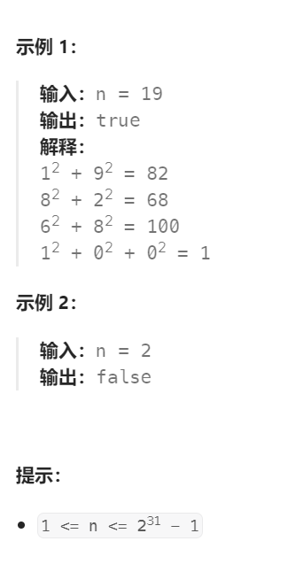

### 使用集合

```python
class Solution:
    def isHappy(self, n: int) -> bool:
        record = set() # 因为这题我们只是想判断是否有重复值，不需要排序，不关心出现过几次

        while n != 1:
            if n in record:
                return False

            record.add(n) # set用add

            next_num = 0
            while n > 0:
                digit = n % 10 # 取小数位
                next_num += digit * digit # 这个地方要用 +=，而不是 =，这里要把 每一位的平方累加起来，而不是只保留 最后一位数字的平方
                n //= 10 # 删除小数位

            n = next_num

        return True
```

### 使用集合 (不同的 while 条件)

```python
class Solution:
   def isHappy(self, n: int) -> bool:
    record = set()

    while n not in record:
        record.add(n)

        new_sum = 0
        n_str = str(n)
        for i in range(len(n_str)):
            new_sum += int(n_str[i]) ** 2
        if new_sum == 1:
            return True
        else: n = new_sum

    return False
```

### 使用数组+精简 （#为集合+精简）

```python
class Solution:
   def isHappy(self, n: int) -> bool:
    record = []
    # record = set()

    while n != 1:
        n = sum(int(i) ** 2 for i in str(n))
        if n in record:
            return False
        record.append(n)
        # record.add(n)
    return True
```

```python
class Solution:
    def get_sum(self, n):
        total = 0
        while n:
            n, r = divmod(n, 10)
            total += r * r
        return total

    def isHappy(self, n: int) -> bool:
        slow = n
        fast = self.get_sum(n)

        while fast != 1 and slow != fast:
            slow = self.get_sum(n)
            fast = self.get_sum(self.get_sum(fast)) # 这里fast一次走两步，所以要写两遍self.get_sum， 只写一遍的话fast就和slow的速度一样了

        return fast == 1 # == 是bool，返回为True / False， 而不是赋值给fast等于1
```

## [1 两数之和](https://leetcode.cn/problems/two-sum/description/)

> 给定一个整数数组 nums 和一个整数目标值 target，请你在该数组中找出 和为目标值 target 的那 两个 整数，并返回它们的数组下标。

> 你可以假设每种输入只会对应一个答案，并且你不能使用两次相同的元素。

> 你可以按任意顺序返回答案。

> /

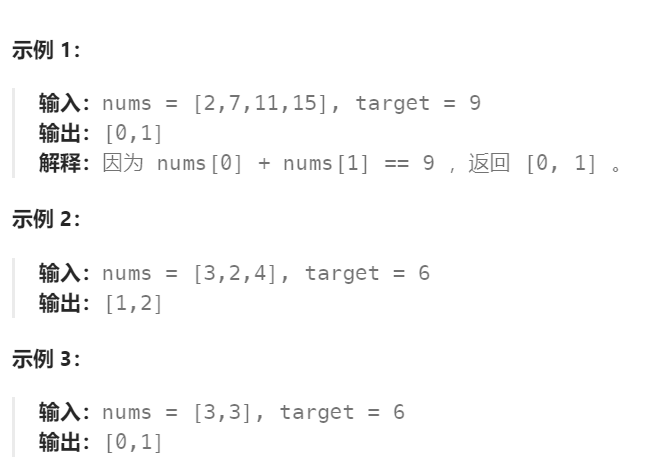

### 暴力法

```python
class Solution(object):
    def twoSum(self, nums, target):
        """
        :type nums: List[int]
        :type target: int
        :rtype: List[int]
        """
        for i in range(len(nums)):
            for j in range(i + 1, len(nums)):
                if nums[i] + nums[j] == target:
                    return [i, j]
```

### 使用字典，不使用enumerate

```python
# 这个解法的思路就是用target减去已经有的值判断这个差值 record里面有没有，有的话说明找到了两数之和，没有的话就继续直到nums循环完成

class Solution:
    def twoSum(self, nums: List[int], target: int) -> List[int]:
        record = {} # record是读一个i存一个数字，而不是一次性读完，所以最少要读到 i=1才能判断两数之和

        for i in range(len(nums)):
            if target - nums[i] in record:
                return [record[target - nums[i]], i]
            record[nums[i]] = i # 如果只读了 i = 0 的话现在record里面只有一个数字，没法做两数之和，所以要把读的数字存进record然后读下一个

        return []
```

### 使用字典，使用enumerate

```python
class Solution:
    def twoSum(self, nums: List[int], target: int) -> List[int]:
        record = {}

        # enumerate 等价于：
        # index = 0
        # for value in nums:
            # 使用 index 和 value
            # index += 1

        # for index, value in enumerate(nums):这一行已经自动初始化并更新了 index 和 value, 所以这里我们不需要再手动初始化index, value
        for index, value in enumerate(nums):
            if target - value in record: # 遍历当前元素，并在map中寻找是否有匹配的key
                return [record[target - value], index]
            record[value] = index

        return []
```